# 00_agrupación jerárquica

Profesora Carolina Luque

**Resultado de aprendizaje:** Analiza datos de diversa índole mediante técnicas de estadística descriptiva y probabilidad.

**Encuentro final**

**Temas:**

- Aplicación de temas tratados en la unidad.
- Agrupación jerárquica

Es necesario disponer de las siguientes librerias:

- `Pandas` y `numpy` para cargar el conjunto de datos y hacer la gestión de los mismos.
- `Scikit-learn` para normalizar los datos.
- `Seaborn` y `matplotlib` para visualización.
- `Scipy` para aplicar el algoritmo de agrupación jerárquica.

```python
# importar librerias y módulos
import pandas as pd
import numpy as np
import seaborn as sns
import matplotlib.pyplot as plt

from sklearn.preprocessing import StandardScaler  # normalizar los datos
from scipy.spatial.distance import pdist, squareform  # cálculo de distancias
from scipy.cluster.hierarchy import linkage, dendrogram, fcluster  # agrupación jerárquica
from scipy.cluster.hierarchy import cut_tree  # cortar el dendograma
```

```python
import warnings
warnings.filterwarnings("ignore")
```

# **Introducción**

**Propósito de los algoritmos de agrupación:**

Clasificar observaciones distribuidas al azar en grupos (cluster) de tal modo que **los objetos dentro del mismo grupo sean lo más similares posible** (i.e., alta similitud intra clase), mientras que **los objetos de diferentes grupos sean lo más diferentes posible** (i.e., baja similitud entre clases).

**Para tener en cuenta:**

- Los grupos **no estan definidos a priori**.
- Métodos **no supervisados**.
- Es necesario considerar una medida de **distancia**.
- Las preguntas a resolver son **¿cuántos grupos? ¿cómo asignar los individuos a los grupos?**

**Aplicaciones**

- Segmentación de clientes teniendo en cuenta características sociodemográficas o patrones consumo para fines de marketing dirigido y recomendaciones de productos.
- Agrupar pacientes según su perfil demográfico y su historia clinica para ofrecer programas de prevención y promoción de salud específicos para cada grupo demográfico.

Existen varios enfoques de agrupamiento, en particular vamos estudiar el **algoritmo de agrupación jerárquica**, una técnica de aprendizaje automático no supervisado que se utiliza para agrupar datos no etiquetados en categorías similares.

# **Agrupación jerárquica**

El **agrupamiento jerárquico** (también denominado clúster jerárquico o análisis de conglomerado jerárquico) es un enfoque se segmentación que permite agrupar objetos basados en su **similitud**. Los grupos surgen de agrupaciones sucesivas a partir de grupos previamente establecidos.

En contraste con otros métodos de agrupamiento, no requiere especificar previamente el número de clústeres en que se va a particionar los datos.

La agrupación jerárquica se puede subdividir en dos tipos:

- **Agrupación aglomerativa** en la que cada observación se considera inicialmente como una racimo propio (hoja). Luego, los clústeres más similares se fusionan sucesivamente hasta que haya un solo grupo grande (raíz).
- **Agrupación divisiva** que es un procedimiento inverso al agrupamiento aglomerativo. Comienza con la raíz, en la que todos los objetos están incluidos en un grupo. Entonces, los más heterogéneos se dividen sucesivamente hasta que todas las observaciones son en si mismos un grupo.

El resultado de la agrupación es un árbol de conglomerados llamado [dendograma](https://es.wikipedia.org/wiki/Dendrograma), que representa gráficamente la relación jerárquica entre los grupos subyacentes. Ver la figura a continuación.

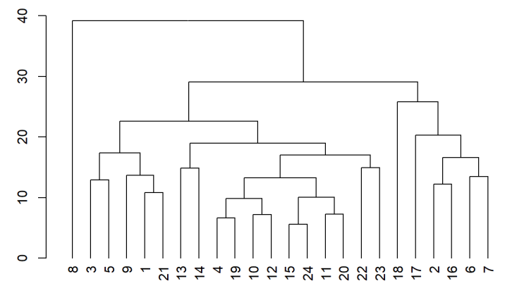

## **Ejemplo: USArrests**

El conjunto de datos **USArrests** contiene estadísticas relacionadas con arrestos por cada 100000 residentes por asalto, asesinato, y violación en cada uno de los 50 estados de Estados Unidos para el año 1973. También se tiene el porcentaje de la población que vive en áreas urbanas.

Las variables son:

- Muerder (asesinato) : Arrestos por asesinato por cada 100000 habitantes.
- Assault (asalto) : Arrestos por asalto por cada 100000 habitantes.
- UrbanPop (población urbana) : Porcentaje de población urbana.
- Rape (violación) : Arrestos por violación por cada 100000 habitantes.

**Nota**: las variables son cuantitativas.

```python
# carga el archivo CSV con pandas
df = pd.read_csv("/content/drive/MyDrive/EstadisticaProbabilidad_EspecializacionML/data/USArrests.csv",index_col=0)
print(df.head())
```

```
            Murder  Assault  UrbanPop  Rape
Alabama       13.2      236        58  21.2
Alaska        10.0      263        48  44.5
Arizona        8.1      294        80  31.0
Arkansas       8.8      190        50  19.5
California     9.0      276        91  40.6
```

### **Análisis descriptivo**

```python
# resumen de los datos
df.describe()
```

|  | Murder | Assault | UrbanPop | Rape |
| --- | --- | --- | --- | --- |
| count | 50.00000 | 50.000000 | 50.000000 | 50.000000 |
| mean | 7.78800 | 170.760000 | 65.540000 | 21.232000 |
| std | 4.35551 | 83.337661 | 14.474763 | 9.366385 |
| min | 0.80000 | 45.000000 | 32.000000 | 7.300000 |
| 25% | 4.07500 | 109.000000 | 54.500000 | 15.075000 |
| 50% | 7.25000 | 159.000000 | 66.000000 | 20.100000 |
| 75% | 11.25000 | 249.000000 | 77.750000 | 26.175000 |
| max | 17.40000 | 337.000000 | 91.000000 | 46.000000 |

Las cuatro variables muestran una **alta dispersión con respecto a su media**, esto se puede evidenciar en la diferencia entre el mínimo y el máximo, y en la desviación estándar con respeto a su media.

```python
# matriz de correlaciones
correlation_matrix = df.corr()
print("Matriz de correlaciones:")
print(correlation_matrix)
```

```
Matriz de correlaciones:
            Murder   Assault  UrbanPop      Rape
Murder    1.000000  0.801873  0.069573  0.563579
Assault   0.801873  1.000000  0.258872  0.665241
UrbanPop  0.069573  0.258872  1.000000  0.411341
Rape      0.563579  0.665241  0.411341  1.000000
```

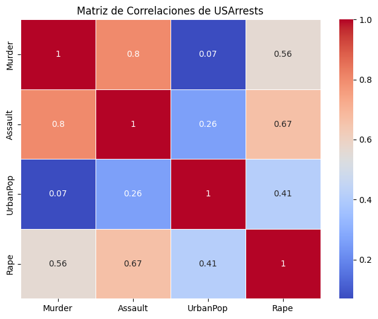

```python
# mapa de calor
plt.figure(figsize=(8, 6))
sns.heatmap(correlation_matrix, annot=True, cmap='coolwarm', linewidths=0.5)
plt.title("Matriz de Correlaciones de USArrests")
plt.show()
```

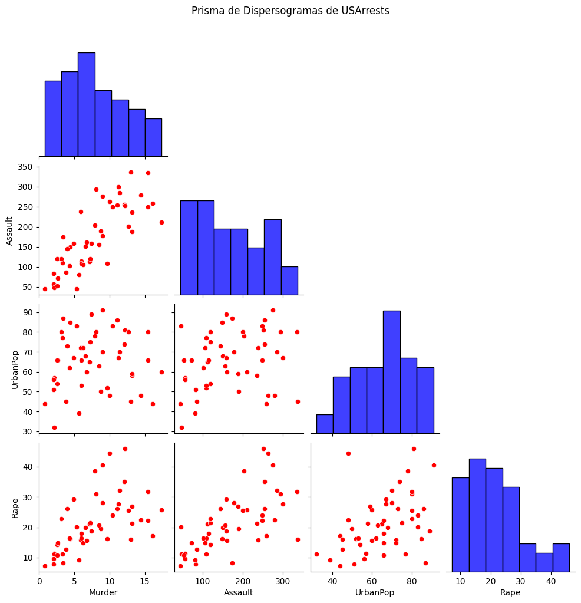

```python
# dispersogramas
sns.pairplot(df, plot_kws={'color': 'red'}, diag_kws={'color': 'blue'}, markers='o', corner=True)
plt.suptitle("Prisma de Dispersogramas de USArrests", y=1.02)
plt.show()
```

En la matriz de correlaciones se evidencia una **asociación directa entre las variables asalto y asesinato**, **asesinato y violación**. La variable violación tiene una relación positiva con todas las demás variables. La variable porcentaje de población urbana no muestra una asociación contundente con las demás variables.

### **Preprocesamiento de los datos**

Antes de aplicar la técnica de agrupación jerárquica, es conveniente preprocesar los datos:

- Verificar el porcentaje de datos faltantes y tratarlos según sea adecuado.
- Analizar valorés atipícos.
- Normalizar observaciones de las variables.
- Eliminar las columnas irrelevantes.

#### **Valores faltantes**

```python
# porcentaje de datos perdidos por variable
percent_missing = round(100*(df.isnull().sum())/len(df),2)
percent_missing
```

|  | 0 |
| --- | --- |
| Murder | 0.0 |
| Assault | 0.0 |
| UrbanPop | 0.0 |
| Rape | 0.0 |

**dtype:** float64

#### **Valores atípicos**

La sensibilidad a los valores atípicos es una débilidad de la agrupación jerárquica debido a que se basa en el cálculo de distancias entre individuos y grupos.

- Un valor atípico, por estar muy alejado de la mayoría de las observaciones, puede aumentar considerablemente la distancia promedio o mínima entre clústeres.
- Un valor atípico puede hacer que se formen clústeres no representativos de los patrones generales de los datos. En otras palabras, un valor atípico podría forzar al algoritmo a crear un clúster separado, o a fusionarlo incorrectamente con otros clústeres, distorsionando la jerarquía.

Para reducir la influencia de los valores atípicos en la agrupación jerárquica, algunas soluciones incluyen:

- Eliminar los valores atípicos previamente utilizando técnicas como el análisis de la distribución de los datos o métodos robustos para la detección de outliers.
- Normalizar o escalar de las variables para que los outliers no tengan un impacto tan grande en el cálculo de distancias.

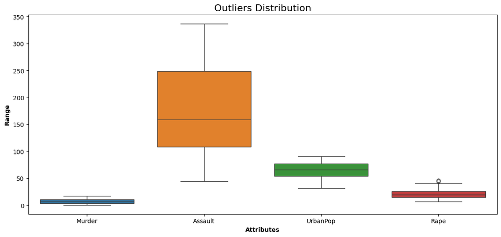

```python
# análisis de valores atípicos
def show_boxplot(df):
  plt.rcParams['figure.figsize'] = [14,6]
  sns.boxplot(data = df, orient="v")
  plt.title("Outliers Distribution", fontsize = 16)
  plt.ylabel("Range", fontweight = 'bold')
  plt.xlabel("Attributes", fontweight = 'bold')

show_boxplot(df)
```

```python
# función para eliminar outliers
def remove_outliers(data):
    df = data.copy()
    filter_condition = pd.Series([True] * len(df), index=df.index)

    for col in df.select_dtypes(include=['float64', 'int64']).columns:
        Q1 = df[col].quantile(0.25)
        Q3 = df[col].quantile(0.75)
        IQR = Q3 - Q1
        lower_bound = Q1 - 1.5 * IQR
        upper_bound = Q3 + 1.5 * IQR
        filter_condition &= (df[col] >= lower_bound) & (df[col] <= upper_bound)

    df = df[filter_condition]
    return df
```

```python
without_outliers = remove_outliers(df)
```

[figure not shown]

```python
show_boxplot(without_outliers)
```

```python
without_outliers.head()
```

|  | Murder | Assault | UrbanPop | Rape |
| --- | --- | --- | --- | --- |
| Alabama | 13.2 | 236 | 58 | 21.2 |
| Arizona | 8.1 | 294 | 80 | 31.0 |
| Arkansas | 8.8 | 190 | 50 | 19.5 |
| California | 9.0 | 276 | 91 | 40.6 |
| Colorado | 7.9 | 204 | 78 | 38.7 |

```python
# individuos que se remueven del conjunto de datos
print(df.shape)
print(without_outliers.shape)
print('-'*100)
diferencias_filas = pd.concat([df, without_outliers]).drop_duplicates(keep=False)
print(diferencias_filas)
```

[output not shown]

#### **Normalizar o escalar las variables**

Las medidas de similaridad pueden ser muy sensibles a las unidades en que estan medidas las variables. Si se hacen agrupaciones en función de variables no conmesurables lo más probable es que algunas de ellas contribuyan más que otras a establecer los grupos. Conceptualemnte esto no se debe a que algunas variables sean más importantes que otras, sino que, dependiendo de las unidades de medida en que se midan, las diferencias en valor absoluto siempre serán muy superiores frente a las demás.

Para evitar la influencia no deseable de una variable debida exclusivamente a la unidad en que viene medida, es necesario recurrir a un proceso de normalización (estandarización o escalamiento). En la práctica hay varias opciones:

- **Puntuaciones Z**: A los valores de la variable se les resta su respectivo promedio y se dividen en su desviación estándar. De esta forma la variable estandarizada tiene media 0 y desviación estándar 1.
- **Rango 1**: Los valores de la variable se dividen por su rango. De esta forma el rango de variación de la variable estandarizada queda reducido a un intervalo de valor 1.
- **Rango 0 a 1**: A los valores de la variable se les resta su valor mínimo y se dividen por el rango. De esta forma el valor mínimo de la variable estandarizada es 0 y el máximo 1.

```python
# normalizar - puntuaciones Z
data_scaler = StandardScaler()

scaled_data = data_scaler.fit_transform(without_outliers)
print(type(scaled_data))
print(scaled_data.shape)
```

```
<class 'numpy.ndarray'>
(48, 4)
```

# **Algoritmo de agrupación jerárquica**

Los pasos que sigue una agrupación aglomerativa son:

1. Iniciar con $C_1, C_2, \dots, C_n$ donde cada $C_j$ con $j=1,\cdots,n$ es un individuo considerado un grupo. Es decir, en principio se tienen $n$ grupos ($K=n$).
2. Determinar y unir los cluster más *cercanos*, $C_i$ y $C_j$.
3. Repetir el proceso para ir decreciendo el número de cluster de uno en uno.
4. Detener cuando $K=1$.

## **Distancias (similaridad) entre individuos**

Cuando las variables que se utilizan son cuantitativas en escala de intervalo o razón, se puede utilizar alguna de las siguentes medidas de similaridad.

- **Euclidiana**: $\quad d_{ij} = \sqrt{\sum_{l=1}^{m} (x_{i,l}-x_{j,l})^2}$
- **Manhattan**: $\quad d_{ij}=\sum_{l=1}^{m} \mid x_{i,l}-x_{j,l} \mid^p$
- **Minkowski**: $\quad d_{ij}= \left[ \sum_{l=1}^{m} (x_{i,l}-x_{j,l})^p) \right]^\frac{1}{p}$

Donde $x_{i,l}$ y $x_{j,l}$ representan el valor dos observaciones $i$ y $j$ en la variable $l$. $m$ es el total de variables observadas y $p$ es un entero.

## **Distancias entre clusters**

Sean $A$ y $B$ dos cluster.

- **Agrupamiento de un solo enlace o método del vecino más cercano** (*single linkage clustering*): $$ d_{AB} = \text{min}_{i \in A, j \in B}\{d_{ij}\}$$
- **Agrupamiento de enlaces completo o método del vencino más lejano** (*complete linkage clustering*): $$ d_{AB} = \text{max}_{i \in A, j \in B}\{d_{ij}\}$$
- **Agrupamiento promedio de grupo o método de vinculación promedio** (*group average clustering*): $$ d_{AB} = \frac{1}{n_A n_B} \sum_{i \in A} \sum_{j \in B} \{ d_{ij}\}$$

```python
# implementación del algoritmo con diferentes funciones de enlace
complete_clustering = linkage(scaled_data, method="complete", metric="euclidean")
average_clustering = linkage(scaled_data, method="average", metric="euclidean")
single_clustering = linkage(scaled_data, method="single", metric="euclidean")
```

## **Ejemplo: USArrests**

En los siguientes gráficos

- El eje x del dendrograma representa los individuos (estados).
- El eje y representa la distancia (en este caso Euclideana) entre individuos o grupos. A mayor longitud de la línea vertical, más disímiles son los individuos o clusters.

Cada línea vertical del diagrama representa un agrupamiento. Los grupos se van formando progresivamente hasta tener un solo gran grupo determinado por todas las observaciones.

[figure not shown]

```python
dendrogram(complete_clustering, labels = without_outliers.index)
plt.title("Dendrograma con método 'complete'")
plt.xlabel("Estados")
plt.ylabel("Distancia")
plt.show()
```

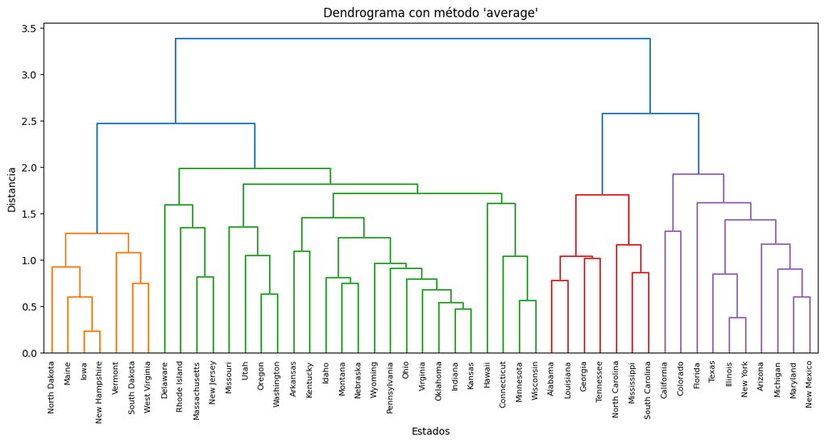

```python
dendrogram(average_clustering, labels = without_outliers.index)
plt.title("Dendrograma con método 'average'")
plt.xlabel("Estados")
plt.ylabel("Distancia")
plt.show()
```

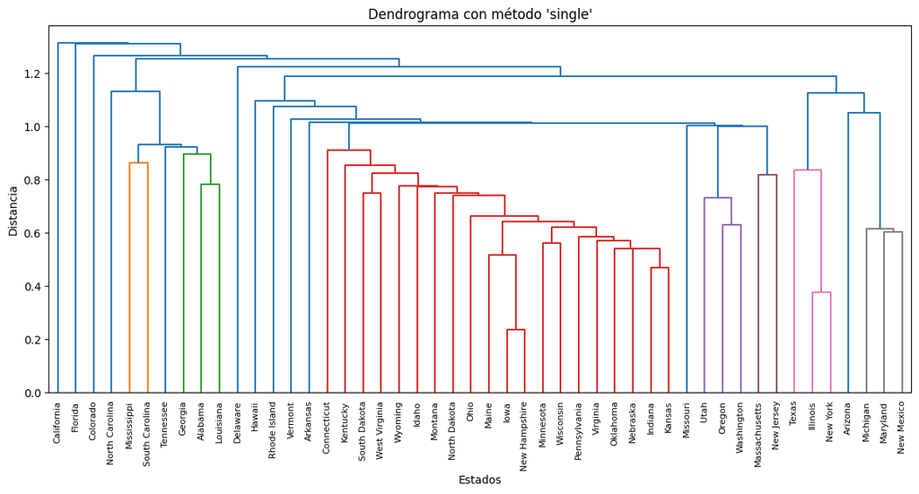

```python
dendrogram(single_clustering, labels = without_outliers.index)
plt.title("Dendrograma con método 'single'")
plt.xlabel("Estados")
plt.ylabel("Distancia")
plt.show()
```

## **Número óptimo de grupos**

En la agrupación jerárquica, el **número óptimo** de conglomerados puede determinarse a partir del dendrograma identificando la **línea vertical de mayor distancia** que no tenga ninguna intersección con otros conglomerados.

En otras palabras, la idea es examinar las magnitudes de los cambios del altura en el dendograma y tomar un "gran cambio" para indicar el número apropiado de grupos para segmentar el conjunto de datos.

Lo anterior es una **justificación empirica**. Sin embargo, la decisión en relación al número de agrupaciones es subjetiva y suele guiarse por el conocimiento que tiene el análista de los datos. Así, el dendrograma se corta a la altura que mejor representa los datos.

```python
# vector con los grupos
cluster_labels = cut_tree(complete_clustering, n_clusters=4).reshape(-1, )
without_outliers["Cluster"] = cluster_labels
```

```python
without_outliers.head()
```

[output not shown]

## **Caracterizar las agrupaciones**

Una vez se tienen los grupos es importante caracterizarlos desde el punto de vista estadístico y del contexto.

```python
# contar cuántos estados hay en cada clúster
cluster_counts = without_outliers['Cluster'].value_counts()

# imprimir resultados
print("Conteo de estados por clúster:")
print(cluster_counts)
```

```
Conteo de estados por clúster:
Cluster
2    18
3    13
1    10
0     7
Name: count, dtype: int64
```

```python
# calcular medidas descriptivas para cada grupo
descriptive_stats = without_outliers.groupby('Cluster').agg(['mean', 'std', 'min', 'max'])
print("\nMedidas descriptivas por clúster:")
print(descriptive_stats)
```

[output not shown]

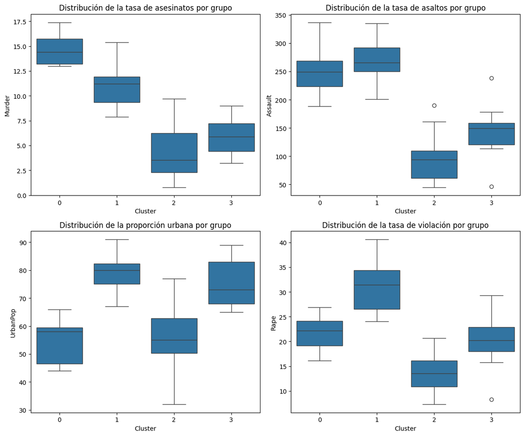

```python
# crear una cuadrícula de 2x2 para los boxplots
fig, axes = plt.subplots(2, 2, figsize=(12, 10))

# graficar cada boxplot en su respectiva subgráfica
sns.boxplot(x='Cluster', y='Murder', data=without_outliers, ax=axes[0, 0])
axes[0, 0].set_title('Distribución de la tasa de asesinatos por grupo')

sns.boxplot(x='Cluster', y='Assault', data=without_outliers, ax=axes[0, 1])
axes[0, 1].set_title('Distribución de la tasa de asaltos por grupo')

sns.boxplot(x='Cluster', y='UrbanPop', data=without_outliers, ax=axes[1, 0])
axes[1, 0].set_title('Distribución de la proporción urbana por grupo')

sns.boxplot(x='Cluster', y='Rape', data=without_outliers, ax=axes[1, 1])
axes[1, 1].set_title('Distribución de la tasa de violación por grupo')

# ajustar el espacio entre subgráficas
plt.tight_layout()
plt.show()
```

```python
# convertir los nombres de los índices en una columna llamada "State"
without_outliers = without_outliers.reset_index().rename(columns={'index': 'State'})
without_outliers.head()
```

|  | State | Murder | Assault | UrbanPop | Rape | Cluster |
| --- | --- | --- | --- | --- | --- | --- |
| 0 | Alabama | 13.2 | 236 | 58 | 21.2 | 0 |
| 1 | Arizona | 8.1 | 294 | 80 | 31.0 | 1 |
| 2 | Arkansas | 8.8 | 190 | 50 | 19.5 | 2 |
| 3 | California | 9.0 | 276 | 91 | 40.6 | 1 |
| 4 | Colorado | 7.9 | 204 | 78 | 38.7 | 1 |

```python
# listar los nombres de los estados que pertenecen a cada clúster
states_per_cluster = without_outliers.groupby('Cluster')['State'].apply(list)  # Asegúrate de que la columna de nombres de estados sea correcta
```

```python
# grupo 1
print("Estados por clúster 1:")
print(states_per_cluster[0])
```

```
Estados por clúster 1:
['Alabama', 'Georgia', 'Louisiana', 'Mississippi', 'North Carolina', 'South Carolina', 'Tennessee']
```

Los estados de este grupo se destacan por tener **altas tasas de asesinato y asalto**, junto con una **proporción urbana y tasa de violaciones moderadas**.

# **Práctica 1. Revisión de conceptos**

Esta es una actividad **individual** con una duración estimada de **20 minutos**. La prueba consta de **dos (2) intentos**, y se registrará la **calificación más alta**.

**Objetivo**: Evaluar los conceptos estudiados hasta el momento.

**Puntuación**: Esta actividad tendrá una puntuación máxima de 5 puntos.

**Pasos a seguir**:

1. Acceder a Canvas e ir a la sección de Evaluaciones. Allí encontran la prueba titulada *Agrupación Jerárquica*.
2. Completar la prueba teniendo en cuenta la explicación previa y consultando los enlaces indicados.

¡Mucha suerte!

# **Práctica 2. Prestamos**

**Contexto**

El conjunto de datos [loan_data.csv](https://www.kaggle.com/datasets/itssuru/loan-data?resource=download) tiene registros de 9578 préstamos. Las variables estan relacionadas con la estructura del préstamo y atributos del prestatario. Estos datos se extrajeron de LendingClub.com, que es una empresa que conecta a prestatarios con inversores.

A continuación, el diccionario del conjunto de datos.

**Diccionario de datos**

| Variable | Tipo | Descripción |
| --- | --- | --- |
| credit_policy | Categórica | 1 si el cliente cumple con los criterios de concesión de crédito; 0 de lo contrario. |
| purpose | Carácter | El propósito del préstamo. |
| int_rate | Numérica | La tasa de interés del préstamo (los prestatarios con mayor riesgo reciben tasas más altas). |
| installment | Numérica | Las cuotas mensuales que debe el prestatario si se financia el préstamo. |
| log_annual_inc | Numérica | El logaritmo natural del ingreso anual autodeclarado del prestatario. |
| dti | Numérica | La relación deuda-ingreso del prestatario (cantidad de deuda dividida por el ingreso anual). |
| fico | Numérica | El puntaje de crédito FICO del prestatario. |
| days_with_cr_line | Numérica | El número de días que el prestatario ha tenido una línea de crédito. |
| revol_bal | Numérica | El saldo revolvente del prestatario (monto no pagado al final del ciclo de facturación de la tarjeta). |
| revol_util | Numérica | La tasa de utilización de la línea de crédito revolvente del prestatario (monto utilizado relativo al total disponible). |
| inq_last_6mths | Numérica | El número de consultas de los acreedores sobre el prestatario en los últimos 6 meses. |
| delinq_2yrs | Numérica | El número de veces que el prestatario ha estado con un pago vencido de más de 30 días en los últimos 2 años. |
| pub_rec | Numérica | El número de registros públicos derogatorios del prestatario. |
| not_fully_paid | Categórica | 1 si el préstamo está pago; 0 de lo contrario. |

**Condiciones para realizar la actividad**

- **Integrantes por grupo**: máximo cuatro personas.
- **Tiempo estimado**: 1 hora y 30 minutos.
- **Producto**: dos (2) archivos `.ipynb` y `html` con el informe correspondiente al desarrollo de la actividad.
- **Puntuación máxima**: 15 puntos.
- **Envio**: Canvas
- **Fecha máxima de entrega**: 07 de octubre de 2024 a las 23:59

**Actividad a realizar**

1. Cargar el archivo **loan_data.csv**, visualizar la primeras observaciones y revisar su estructura utilizando la función `df.info()`.
2. (1.5 puntos) Construir una tabla de frecuencias para la variable `purpose`.
3. (1.5 puntos) Filtrar la base de datos
- ***Para los asistentes al encuentro final***. Consolidar una base de datos considerando solo la categoría `credit_card` de la variable `purpose`. Es decir, los asistentes al encuentro trabajaran con los prestamos de la categoría tarjeta de crédito. A este conjunto de datos nos vamos a referir como el conjunto de datos original `df`.
- ***Para quienes optarán por la prueba extemporánea***. Consolidar una base de datos considerando solo la categoría `small_business` de la variable `purpose`. Es decir, las personas que opten por la actividad extemporánea trabajaran con los prestamos de la categoría pequeñas empresas. A este conjunto de datos nos vamos a referir como el conjunto de datos original `df`.

Presente un resumen descriptivo del conjunto de datos original.

4. (3 puntos) **Preprocesamiento de los datos**. Por favor, seguir los pasos en el orden indicado:
   - Examinar el porcentaje de datos faltantes por variable. En caso de tener datos faltantes, eliminarlos.
   - Remover la variable categórica: `purpose`.
   - Realizar un análisis de datos atípicos utilizando diagramas de caja. Solo considerar variables numericas (`df_num`) y no eliminar los datos atipicos.
   - Normalizar el conjunto de datos que tiene variables numéricas (`df_num`) utilizando el método MiniMaxScaler.

   ```
   from sklearn.preprocessing import MinMaxScaler

   # supongamos que df_num es el data frame
   # crear una instancia de MinMaxScaler
   scaler = MinMaxScaler()

   # ajustar y transformar el data frame
   scaled_data = scaler.fit_transform(df_num)

   # convertir los datos escalados a data frame y mantener los nombres de las columnas
   df_scaled = pd.DataFrame(scaled_data, columns=df_num.columns)
   ```

   - Realizar nuevamente un análisis de datos atípicos utilizando diagramas de caja sobre el conjunto de datos escalado (`df_scaled`).
   - Conformar un conjunto de datos denominado `df_selec` con las variables cuyo comportamiento después de normalizadas es aproximadamente simétrico con respecto a sus medidas de centro o no exhiben datos atipicos. Es decir, `log.annual.inc`, `dti`, `fico` y `revol.util`. Con el conjunto `df_selec` implementar el algoritmo de agrupación jerárquica en el paso 5.

   Finalmente, sintetizar e interpretar los resultados del preprocesamiento en un párrafo.
5. (3 puntos) **Implementar el algoritmo de agrupación jerárquica**. Utilizando el conjunto `df_selec` proponer cuatro escenarios variando la métrica para el cálculo de distancias entre individuos y el método de distancias entre grupos. Para cada escenario, construir su respectivo dendograma.
   - Métricas disponibles para calcular la distancia entre observaciones: `euclidean`, `cityblock`, `manhattan`, `minkowski`, `cosine`, `hamming`, `jaccard` y `chebyshev`.
   - Métodos disponibles para calcular distancias entre grupos:
     - `single`: Menor distancia entre las observaciones de los grupos (enlace simple).
     - `complete`: Mayor distancia entre las observaciones de los grupos (enlace completo).
     - `average`: Promedio de las distancias entre todas las observaciones de los grupos (enlace promedio).
     - `weighted`: Promedio ponderado de las distancias entre los grupos (enlace ponderado).
     - `centroid`: Distancia entre los centroides (centro de masa) de los grupos.
     - `median`: Mediana de las distancias entre las observaciones de los grupos (enlace mediano).
     - `ward`: Minimiza el aumento de la varianza dentro de los grupos al combinarlos (utiliza distancia euclidiana).
6. (3 puntos) **Elección del número óptimo de grupos**. De los escenarios propuestos, seleccionar el que consideren permite segmentar a los individuos de manera adecuada. Describir brevemente la métrica y el método que utilizan, mencionando sus ventajas y desventajas con respecto a otras opciones. Seleccionar el número óptimo de grupos y explicar las razones detrás de sus elecciones.

   Asignar el grupo correspondiente a cada individuo del conjunto de datos original.

```
# crear una columna con el grupo asignado
df["Cluster"] = cluster_labels
```

```
¿Cuántos individuos quedan en cada grupo?
```

7. (3 puntos) **Caracterización de los grupos**. El conjunto de datos original tienen todas las variables más la variable `Cluster`. Realizar un resumen descriptivo de los grupos e incluyan diagramas de caja para comparar su comportamiento en cada variable. ¿Cuáles son las variables que permiten diferenciar entre los grupos y cuáles no? Describan los grupos considerando únicamente las variables que los distinguen claramente. ¿cuál es el comportamiento de las variables categóricas por grupo?

# **Referencias**

- Rajagopalan, G. (2021). A Python Data Analyst's Toolkit: Learn Python and Python-based Libraries with Applications in Data Analysis and Statistics. Springer.
- Igual, L. and Seguí, S. (2017). Introduction to Data Science A Python Approach to Concepts, Techniques and Applications. Springer.
- Haslwanter, T. (2016). An Introduction to Statistics with Python With Applications in the Life Sciences. Springer.